# geobounds: Download administrative boundaries in R

**Important**

The package code is MIT licensed. Always acknowledge **geoBoundaries** when sharing downloaded boundaries or derived figures. Check the boundary metadata for any additional source attribution and licensing requirements before reuse.

## Introduction

The **geobounds** package provides an interface for downloading and working with administrative boundaries from the Global Database of Political Administrative Boundaries, maintained by [**geoBoundaries**](https://www.geoboundaries.org/) (Runfola et al. 2020).

The default **gbOpen** release type covers countries worldwide across multiple ADM levels. Its boundaries use multiple open licenses, including ODbL, CC BY and CC BY-SA. The package also supports **gbHumanitarian** and **gbAuthoritative**, which differ in their sources, validation processes and licensing. With **geobounds**, you can download boundaries as **sf** objects, inspect boundary metadata, cache downloaded files and integrate boundaries into spatial workflows.

This vignette keeps the main workflow in one place. It first explains how to choose a boundary type, then covers cache management and finishes with a spatial analysis example.

## Understanding the boundaries

The **geoBoundaries** database supports commercial, non-commercial and academic uses, subject to the license reported for each boundary. Its quality assurance includes manual review and hand digitization of physical maps where necessary.

This precision comes at a cost: some files can be quite large and may take longer to download. For visualization or general mapping purposes, the [simplified boundaries](https://www.geoboundaries.org/simplifiedDownloads.html) are less accurate but faster to render. Request them by setting `simplified = TRUE`.

```r
library(geobounds)
library(ggplot2)
library(dplyr)

# Compare resolutions.
norway <- gb_get_adm0("NOR") |>
  mutate(res = "Full resolution")
print(object.size(norway), units = "Mb")
```

```
#> 26.5 Mb
```

```r
norway_simp <- gb_get_adm0(country = "NOR", simplified = TRUE) |>
  mutate(res = "Simplified")
print(object.size(norway_simp), units = "Mb")
```

```
#> 1.5 Mb
```

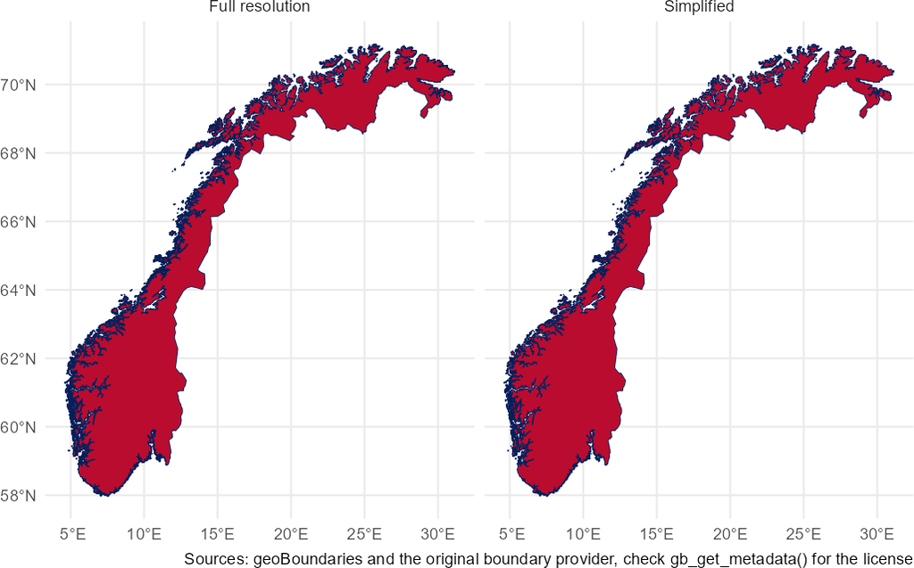

Comparison between full-resolution and simplified boundaries.

```r
norway_all <- bind_rows(norway, norway_simp)

# Plot the boundaries.
ggplot(norway_all) +
  geom_sf(fill = "#BA0C2F", color = "#00205B") +
  facet_wrap(vars(res)) +
  theme_minimal() +
  labs(
    caption = paste(
      "Sources: geoBoundaries and the original boundary provider,",
      "check gb_get_metadata() for the license"
    )
  )
```

### Individual country boundaries

The **geoBoundaries** API provides [individual country boundaries](https://www.geoboundaries.org/countryDownloads.html) that reflect how countries represent their own boundaries, without special identification of disputed areas.

Download individual country boundaries with `gb_get()` or the `gb_get_adm*()` wrappers. Borders are not guaranteed to align perfectly, gaps may exist between countries and disputed territories may not be represented consistently.

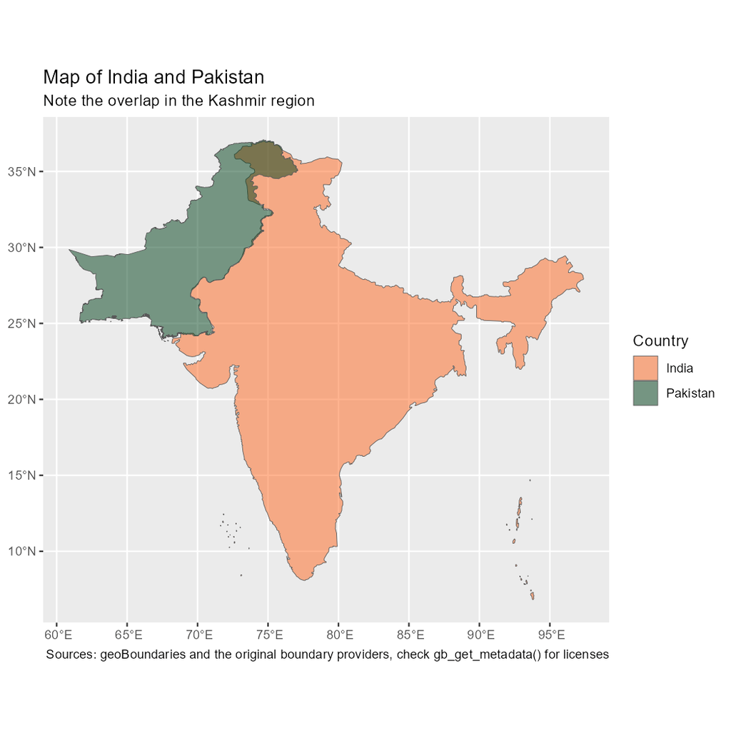

Map showing overlap in the disputed Kashmir area.

```r
india_pak <- gb_get_adm0(c("India", "Pakistan"))

# Highlight the disputed Kashmir area.
ggplot(india_pak) +
  geom_sf(aes(fill = shapeName), alpha = 0.5) +
  scale_fill_manual(values = c("#FF671F", "#00401A")) +
  labs(
    fill = "Country",
    title = "Map of India and Pakistan",
    subtitle = "Note the overlap in the Kashmir region",
    caption = paste(
      "Sources: geoBoundaries and the original boundary providers,",
      "check gb_get_metadata() for licenses"
    )
  )
```

Each individual country boundary is governed by the license identified in its boundary metadata.

```r
gb_get_metadata(c("India", "Pakistan"), adm_lvl = "ADM0") |>
  select(
    boundaryName,
    boundaryLicense,
    boundarySource,
    licenseSource
  )
```

```
#> # A tibble: 2 × 4
#>   boundaryName boundaryLicense                                     boundarySource licenseSource
#>   <chr>        <chr>                                               <chr>          <chr>
#> 1 India        CC0 1.0 Universal (CC0 1.0) Public Domain Dedicati… geoBoundaries… commons.wiki…
#> 2 Pakistan     Open Data Commons Open Database License 1.0         OpenStreetMap… www.openstre…
```

Always acknowledge **geoBoundaries** when sharing a boundary or derived product. Consult the boundary metadata for any additional source attribution, license link, share-alike notice or modification statement required by that boundary’s license. ODbL and CC BY-SA data may impose share-alike obligations beyond attribution.

### Global composite boundaries

Use `gb_get_world()` for global composite boundaries that standardize disputed areas and fill gaps between borders. These boundaries are also known as Comprehensive Global Administrative Zones (CGAZ). They differ from individual country boundaries in three important ways:

1. Extensive simplification keeps file sizes small enough for most desktop software.
2. Disputed areas are removed and replaced with polygons following United States Department of State definitions.
3. Gaps between borders are filled.

CGAZ boundaries and figures are not covered by the package’s MIT license. Follow the citation and use information included in each downloaded CGAZ archive.

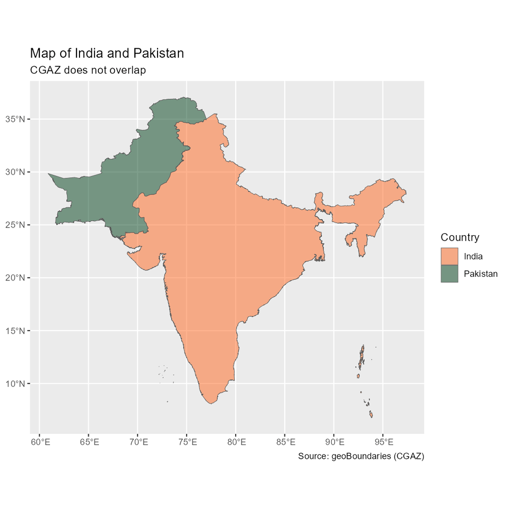

Map showing no overlap in Kashmir, provided by CGAZ.

```r
cgaz_india_pak <- gb_get_world(c("India", "Pakistan"))

ggplot(cgaz_india_pak) +
  geom_sf(aes(fill = shapeName), alpha = 0.5) +
  scale_fill_manual(values = c("#FF671F", "#00401A")) +
  labs(
    fill = "Country",
    title = "Map of India and Pakistan",
    subtitle = "CGAZ does not overlap",
    caption = "Source: geoBoundaries (CGAZ)"
  )
```

## Cache management and performance

**geobounds** stores downloaded files in a cache directory so repeated requests for the same country and ADM level can reuse the cached file. For example:

```r
# Show the current cache directory.
current <- gb_detect_cache_dir()
```

```
#> ℹ 'C:\Users\RUNNER~1\AppData\Local\Temp\Rtmp6LfQDv'
```

```r
current
```

```
#> [1] "C:\\Users\\RUNNER~1\\AppData\\Local\\Temp\\Rtmp6LfQDv"
```

```r
# Change to a new cache directory.
newdir <- file.path(tempdir(), "geoboundvignette")
gb_set_cache_dir(newdir)
```

```
#> ✔ geobounds cache directory is 'C:\Users\RUNNER~1\AppData\Local\Temp\Rtmp6LfQDv/geoboundvignette'.
#> ℹ To use this cache directory in future sessions, call `gb_set_cache_dir()` with `install = TRUE`.
```

```r
# Download the example data.
example <- gb_get_adm0("Vatican City", quiet = FALSE)
```

```
#> ℹ Downloading file from <https://github.com/wmgeolab/geoBoundaries/raw/9469f09/releaseData/gbOpen/VAT/ADM0/geoBoundaries-VAT-ADM0-all.zip>.
#> → Cache directory is 'C:\Users\RUNNER~1\AppData\Local\Temp\Rtmp6LfQDv/geoboundvignette/gbOpen'.
```

```r
# Restore the cache directory.
gb_set_cache_dir(current)
```

```
#> ✔ geobounds cache directory is 'C:\Users\RUNNER~1\AppData\Local\Temp\Rtmp6LfQDv'.
#> ℹ To use this cache directory in future sessions, call `gb_set_cache_dir()` with `install = TRUE`.
```

```r
current == gb_detect_cache_dir()
```

```
#> ℹ 'C:\Users\RUNNER~1\AppData\Local\Temp\Rtmp6LfQDv'
#> [1] TRUE
```

To clear the cache, use `gb_clear_cache()`.

Use the `cache_dir` argument to set a cache directory for an individual function call.

## Spatial analysis workflows

Because boundaries are returned as **sf** objects, you can combine them with other spatial data:

- Clip raster data to administrative units.
- Compute zonal statistics.
- Create choropleth maps.
- Perform spatial joins with survey or tabular data.

This example creates a choropleth map using metadata from individual country boundaries and global composite boundaries from CGAZ:

```r
# Get boundary metadata.
latam_meta <- gb_get_metadata(adm_lvl = "ADM0") |>
  select(boundaryISO, boundaryName, Continent, worldBankIncomeGroup) |>
  filter(Continent == "Latin America and the Caribbean") |>
  glimpse()
```

```
#> Rows: 47
#> Columns: 4
#> $ boundaryISO          <chr> "ABW", "AIA", "ARG", "ATG", "BES", "BHS", "BLM", "BLZ", "BOL", "…
#> $ boundaryName         <chr> "Aruba", "Anguilla", "Argentina", "Antigua and Barbuda", "Bonair…
#> $ Continent            <chr> "Latin America and the Caribbean", "Latin America and the Caribb…
#> $ worldBankIncomeGroup <chr> "High-income Countries", "No income group available", "High-inco…
```

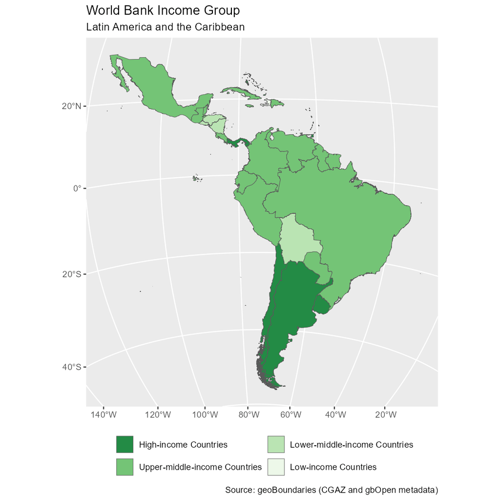

World Bank Income Group: Latin America and the Caribbean.

```r
# Adjust factors.
latam_meta$income_factor <- factor(
  latam_meta$worldBankIncomeGroup,
  levels = c(
    "High-income Countries",
    "Upper-middle-income Countries",
    "Lower-middle-income Countries",
    "Low-income Countries"
  )
)

# Get global composite boundaries from CGAZ.
latam_sf <- gb_get_world(adm_lvl = "ADM0") |>
  inner_join(latam_meta, by = c("shapeGroup" = "boundaryISO"))

ggplot(latam_sf) +
  geom_sf(aes(fill = income_factor)) +
  scale_fill_brewer(palette = "Greens", direction = -1) +
  guides(fill = guide_legend(position = "bottom", nrow = 2)) +
  coord_sf(
    crs = "+proj=laea +lon_0=-75 +lat_0=-15"
  ) +
  labs(
    title = "World Bank Income Group",
    subtitle = "Latin America and the Caribbean",
    fill = "",
    caption = "Source: geoBoundaries (CGAZ and gbOpen metadata)"
  )
```

## Summary

The **geobounds** package supports reproducible workflows for downloading, caching and visualizing administrative boundaries. The returned **sf** objects can be used directly in mapping, spatial analysis and data integration workflows.

## References

Runfola, Daniel, Austin Anderson, Heather Baier, et al. 2020. “geoBoundaries: A Global Database of Political Administrative Boundaries.” *PLOS ONE* 15 (4): 1–9. https://doi.org/10.1371/journal.pone.0231866.